# Class Notes 4.16

today we are enabling copilot

```r
library(tidyverse)
library(readxl)
library(GGally)
library(modeldata)
# load parenting data set

parenting <- read_excel("parenting.xlsx")
```

Glimpse the data set

```r
glimpse(parenting)
```

```
Rows: 100
Columns: 4
$ dan.sleep  <dbl> 7.59, 7.91, 5.14, 7.71, 6.68, 5.99, 8.19, 7.19, 7.40, 6.58,…
$ baby.sleep <dbl> 10.18, 11.66, 7.92, 9.61, 9.75, 5.04, 10.45, 8.27, 6.06, 7.…
$ dan.grump  <dbl> 56, 60, 82, 55, 67, 72, 53, 60, 60, 71, 72, 65, 74, 67, 66,…
$ day        <dbl> 1, 2, 3, 4, 5, 6, 7, 8, 9, 10, 11, 12, 13, 14, 15, 16, 17, …
```

Null: The coefficient of baby.sleep is 0 when dan.sleep is in the model. that is, the true regression equation is dan.grump = B0 + B1dan.sleep + e.

Alt: the coefficient is non-zero

# Plots

ideally, every explanatory varaible in a regression should have a linear relationship with the response variable. a helpful function here is ggpairs

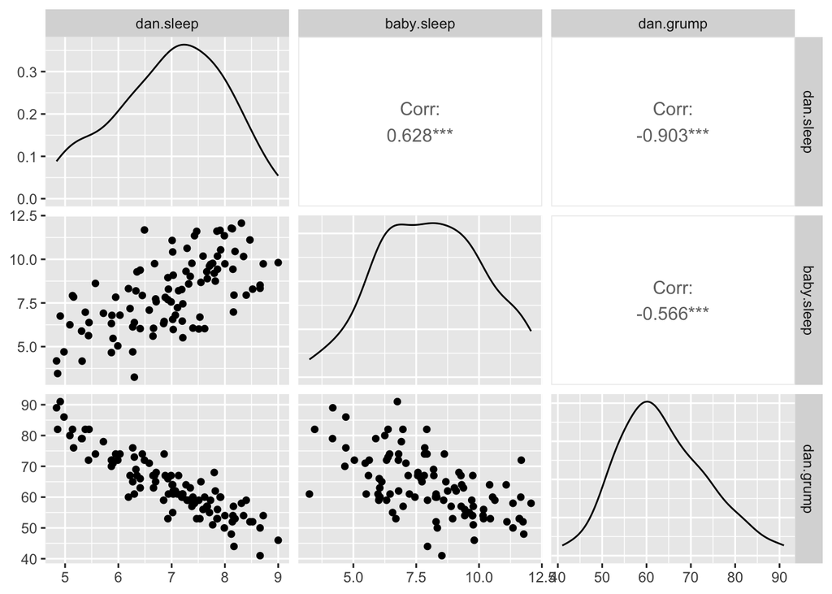

```r
parenting <- parenting %>%
  select(dan.sleep:dan.grump)

GGally::ggpairs(parenting)
```

```r
model <- lm(dan.grump ~ baby.sleep + dan.sleep, data = parenting)

summary(model)
```

```
Call:
lm(formula = dan.grump ~ baby.sleep + dan.sleep, data = parenting)

Residuals:
     Min       1Q   Median       3Q      Max
-11.0345  -2.2198  -0.4016   2.6775  11.7496

Coefficients:
             Estimate Std. Error t value Pr(>|t|)
(Intercept) 125.96557    3.04095  41.423   <2e-16 ***
baby.sleep    0.01052    0.27106   0.039    0.969
dan.sleep    -8.95025    0.55346 -16.172   <2e-16 ***
---
Signif. codes:  0 '***' 0.001 '**' 0.01 '*' 0.05 '.' 0.1 ' ' 1

Residual standard error: 4.354 on 97 degrees of freedom
Multiple R-squared:  0.8161,    Adjusted R-squared:  0.8123
F-statistic: 215.2 on 2 and 97 DF,  p-value: < 2.2e-16
```

The data is consistent with the null, so there is no evidence that baby.sleep is related to dan.grump when dan.sleep is in the model.

## Another perspective on p-values

p-values are often used for variable selection. intuitively, variables with lower p-values feel like they belong in the model. we’ve already seen that this must be done with care. This is called *subset selection*, choosing variables based on p-values

If you do this, it is essential to not double dip, i.e. do not use for inference on the model you selected.

## $R^2$ the coefficient of determination

```r
model2 <- lm(dan.grump ~ dan.sleep, data = parenting)
summary(model2)
```

```
Call:
lm(formula = dan.grump ~ dan.sleep, data = parenting)

Residuals:
    Min      1Q  Median      3Q     Max
-11.025  -2.213  -0.399   2.681  11.750

Coefficients:
            Estimate Std. Error t value Pr(>|t|)
(Intercept) 125.9563     3.0161   41.76   <2e-16 ***
dan.sleep    -8.9368     0.4285  -20.85   <2e-16 ***
---
Signif. codes:  0 '***' 0.001 '**' 0.01 '*' 0.05 '.' 0.1 ' ' 1

Residual standard error: 4.332 on 98 degrees of freedom
Multiple R-squared:  0.8161,    Adjusted R-squared:  0.8142
F-statistic: 434.9 on 1 and 98 DF,  p-value: < 2.2e-16
```

## Multiple Regressions with a categorical variable

Crickets Data Set

```r
glimpse(crickets)
```

```
Rows: 31
Columns: 3
$ species <fct> O. exclamationis, O. exclamationis, O. exclamationis, O. excla…
$ temp    <dbl> 20.8, 20.8, 24.0, 24.0, 24.0, 24.0, 26.2, 26.2, 26.2, 26.2, 28…
$ rate    <dbl> 67.9, 65.1, 77.3, 78.7, 79.4, 80.4, 85.8, 86.6, 87.5, 89.1, 98…
```

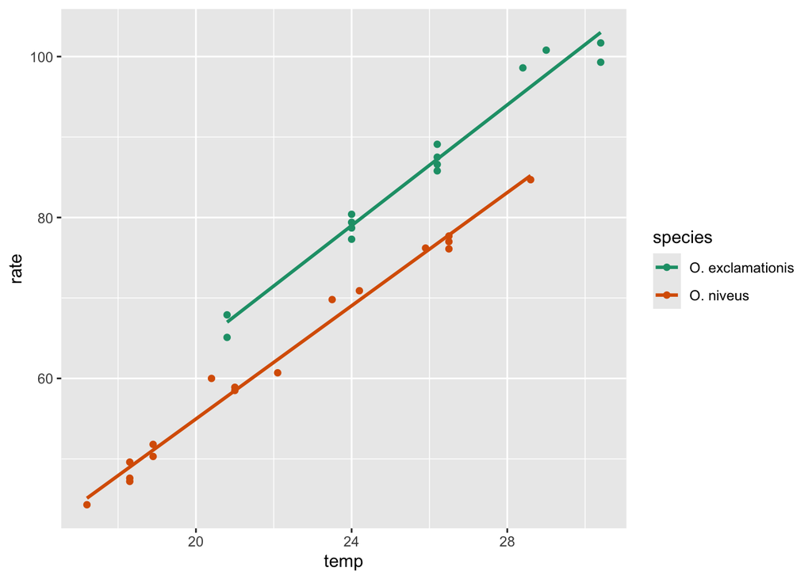

```r
ggplot(crickets,
       aes(x = temp,
           y = rate,
           color = species)) +
  geom_point() +
  geom_smooth(method = "lm",
              se = FALSE) +
  scale_color_brewer(palette = "Dark2")
```

assume slopes in 2 groups are equal and get 2 equations for the lines

O.exclamationis, rate = B0 + B1temp + e and for O.niveus rate = (B0 + B2) + B1temp + e, where B2 is the vertical distance between the two lines.